# Trabalho6

Thiago Tavares Lopes

2025-06-27

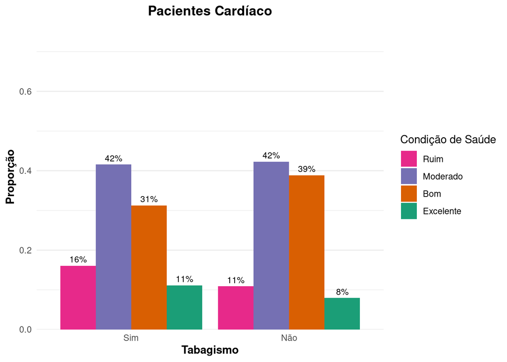

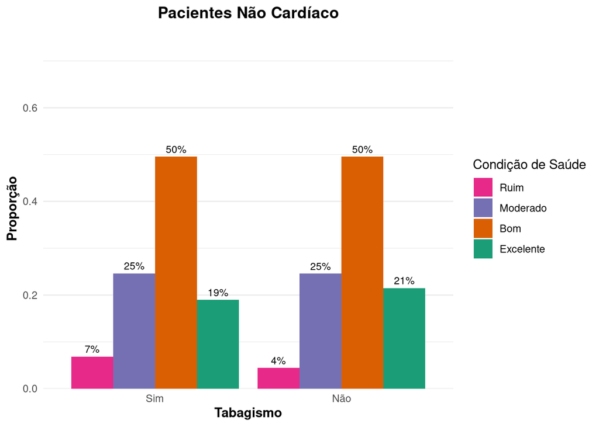

| tabaco | cardiaco | Excelente | Bom | Moderado | Ruim | Total |
| --- | --- | --- | --- | --- | --- | --- |
| Sim | Sim | 27 | 76 | 101 | 39 | 243 |
| Sim | Não | 402 | 1050 | 522 | 145 | 2119 |
| Não | Sim | 83 | 406 | 442 | 114 | 1045 |
| Não | Não | 1959 | 4521 | 2243 | 405 | 9128 |

## Ajuste do modelo para Tabaco

Ajuste dos modelos para chances proporcionais (modelo mais simples) e para chances não proporcionais (modelo mais completo).

No caso, temos que $H_{0}:\text{O modelo de chances proporcionais é o mais adequado}$

```r
# Modelo Tabaco

# Modelo chances não proporcionais
mcnp <- vglm(cbind(Excelente,Bom,Moderado,Ruim) ~ tabaco,
             cumulative(parallel=FALSE,reverse=FALSE), dados)

# Modelo de chances proporcionais
mcp <- vglm(cbind(Excelente,Bom,Moderado,Ruim) ~ tabaco,
            cumulative(parallel=TRUE,reverse=FALSE), dados)

round(coef(mcnp, matrix = TRUE), digits = 3)
```

```
##             logitlink(P[Y<=1]) logitlink(P[Y<=2]) logitlink(P[Y<=3])
## (Intercept)             -1.382              0.777              2.923
## tabacoSim               -0.124             -0.121             -0.452
```

```r
round(coef(mcp, matrix = TRUE), digits = 3)
```

```
##             logitlink(P[Y<=1]) logitlink(P[Y<=2]) logitlink(P[Y<=3])
## (Intercept)             -1.378              0.781              2.852
## tabacoSim               -0.146             -0.146             -0.146
```

```r
# Comparação dos modelos
# TRV <- 2*(logLik(mcnp) - logLik(mcp))
# gl <- length(coef(mcnp)) - length(coef(mcp))
# p <- 1-pchisq(TRV,gl)
# cbind(TRV, gl, p)

lrtest(mcnp, mcp)
```

```
## Likelihood ratio test
##
## Model 1: cbind(Excelente, Bom, Moderado, Ruim) ~ tabaco
## Model 2: cbind(Excelente, Bom, Moderado, Ruim) ~ tabaco
##   #Df  LogLik Df  Chisq Pr(>Chisq)
## 1   6 -218.51
## 2   8 -225.96  2 14.888  0.0005851 ***
## ---
## Signif. codes:  0 '***' 0.001 '**' 0.01 '*' 0.05 '.' 0.1 ' ' 1
```

No caso, para os ajuste do modelo para a variável tabaco:

Como o p-valor foi menor que 0.05, rejeitamos $H_{0}$, e podemos concluir que o modelo de chances proporcionais não é o modelo mais adequado.

## Ajuste do modelo para Cardiaco

Ajuste dos modelos para chances proporcionais (modelo mais simples) e para chances não proporcionais (modelo mais completo).

```r
# Modelos com somente CARDIACO

# Modelo chances não proporcionais
mcnp <- vglm(cbind(Excelente,Bom,Moderado,Ruim) ~ cardiaco,
             cumulative(parallel=FALSE,reverse=FALSE), dados)
# Modelo de chances proporcionais
mcp <- vglm(cbind(Excelente,Bom,Moderado,Ruim) ~ cardiaco,
            cumulative(parallel=TRUE,reverse=FALSE), dados)

#coef(mcnp, matrix = TRUE)
#coef(mcp, matrix = TRUE)

# Comparação dos modelos
# TRV <- 2*(logLik(mcnp) - logLik(mcp))
# gl <- length(coef(mcnp)) - length(coef(mcp))
# p <- 1-pchisq(TRV,gl)
# cbind(TRV, gl, p)

lrtest(mcnp, mcp)
```

```
## Likelihood ratio test
##
## Model 1: cbind(Excelente, Bom, Moderado, Ruim) ~ cardiaco
## Model 2: cbind(Excelente, Bom, Moderado, Ruim) ~ cardiaco
##   #Df  LogLik Df Chisq Pr(>Chisq)
## 1   6 -58.586
## 2   8 -58.880  2 0.588     0.7453
```

No caso, para os ajuste do modelo para a variável cardiaco:

Como o p-valor foi maior que 0.05, não rejeitamos $H_{0}$, e podemos concluir que o modelo de chances proporcionais é o modelo mais adequado.

## Ajuste do modelo para Tabaco + Cardiaco

Neste caso, foram ajustados dois modelos com a relação aditiva entre as variáveis $\text{cardiaco + tabaco}$, são eles :

- Modelo de chances proporcionais (MCP), que assume que os efeitos das covariáveis são constantes entre os diferentes pontos de corte da escala ordinal.
- Modelo de chances não proporcionais (MCNP), que relaxa essa suposição, permitindo que o efeito das covariáveis varie entre os níveis da resposta ordinal.

```r
# CARDIACO E TABACO
# Modelo chances não proporcionais
mcnp <- vglm(cbind(Excelente,Bom,Moderado,Ruim) ~ cardiaco + tabaco,
             cumulative(parallel=FALSE,reverse=FALSE), dados)

# Modelo de chances proporcionais
mcp <- vglm(cbind(Excelente,Bom,Moderado,Ruim) ~ cardiaco + tabaco,
            cumulative(parallel=TRUE,reverse=FALSE), dados)
round(coef(mcnp, matrix = TRUE), digits = 3)
```

```
##             logitlink(P[Y<=1]) logitlink(P[Y<=2]) logitlink(P[Y<=3])
## (Intercept)             -1.302              0.897              3.069
## cardiacoSim             -1.047             -1.036             -0.965
## tabacoSim               -0.127             -0.129             -0.458
```

```r
round(coef(mcp, matrix = TRUE), digits = 3)
```

```
##             logitlink(P[Y<=1]) logitlink(P[Y<=2]) logitlink(P[Y<=3])
## (Intercept)             -1.298              0.901              3.012
## cardiacoSim             -1.026             -1.026             -1.026
## tabacoSim               -0.154             -0.154             -0.154
```

```r
# Comparação dos modelos
# TRV <- 2*(logLik(mcnp) - logLik(mcp))
# gl <- length(coef(mcnp)) - length(coef(mcp))
# p <- 1-pchisq(TRV,gl)
# cbind(TRV, gl, p)

lrtest(mcnp, mcp)
```

```
## Likelihood ratio test
##
## Model 1: cbind(Excelente, Bom, Moderado, Ruim) ~ cardiaco + tabaco
## Model 2: cbind(Excelente, Bom, Moderado, Ruim) ~ cardiaco + tabaco
##   #Df  LogLik Df  Chisq Pr(>Chisq)
## 1   3 -44.922
## 2   7 -52.479  4 15.114   0.004471 **
## ---
## Signif. codes:  0 '***' 0.001 '**' 0.01 '*' 0.05 '.' 0.1 ' ' 1
```

Como o p-valor foi menor que 0.05, rejeitamos $H_{0}$, e podemos concluir que o modelo de chances proporcionais não é o modelo mais adequado.

```r
# Adotando-se o MCNP, vamos comparar os modelos de forma hierárquica
mcnp0 <- vglm(cbind(Excelente,Bom,Moderado,Ruim) ~ 1,
            cumulative(parallel=FALSE,reverse=FALSE), dados)
mcnp1 <- vglm(cbind(Excelente,Bom,Moderado,Ruim) ~ tabaco,
            cumulative(parallel=FALSE,reverse=FALSE), dados)
mcnp2 <- vglm(cbind(Excelente,Bom,Moderado,Ruim) ~ factor(tabaco) + factor(cardiaco),
            cumulative(parallel=FALSE,reverse=FALSE), dados)
mcnp3 <- vglm(cbind(Excelente,Bom,Moderado,Ruim) ~ tabaco*cardiaco,
            cumulative(parallel=FALSE,reverse=FALSE), dados)
# GL = s(r-1)-p; s = 4 (nro combinações de X); r = 3 (nro categorias de Y)
GL_ <- as.numeric(c(8-length(coef(mcnp0)),
         8-length(coef(mcnp1)),
         8-length(coef(mcnp2)),
         8-length(coef(mcnp3))))
Deviance_ <- round(as.numeric(c(deviance(mcnp0),
               deviance(mcnp1),
               deviance(mcnp2),
               deviance(mcnp3))), digits = 2)
TRV_ <- round(as.numeric(c(NA,
         deviance(mcnp0)-deviance(mcnp1),
         deviance(mcnp1)-deviance(mcnp2),
         deviance(mcnp2)-deviance(mcnp3))), digits = 2)
AIC_ <- round(as.numeric(c(AIC(mcnp0),AIC(mcnp1),AIC(mcnp2),AIC(mcnp3))), digits = 2)
Dif_ <- as.numeric(c(NA,
           df.residual(mcnp0)-df.residual(mcnp1),
           df.residual(mcnp1)-df.residual(mcnp2),
           df.residual(mcnp2)-df.residual(mcnp3)))

P_v  <- round(as.numeric(c(NA,
         1-pchisq(TRV_[2],Dif_[2]),
         1-pchisq(TRV_[3],Dif_[3]),
         1-pchisq(TRV_[4],Dif_[4]))), digits = 3)

tab8.7 <- round(cbind(GL_, Deviance_, TRV_, Dif_, P_v, AIC_), digits = 4)
colnames(tab8.7) <- c("GL", "Deviance", "TRV", "Dif", "P-v", "AIC")
rownames(tab8.7) <- c("Nulo", "X1", "X2|X1", "X1*X2|X1,X2")
tab8.7
```

```
##             GL Deviance    TRV Dif   P-v    AIC
## Nulo         5   379.63     NA  NA    NA 469.54
## X1           2   353.12  26.51   3 0.000 449.03
## X2|X1       -1     5.93 347.19   3 0.000 107.84
## X1*X2|X1,X2 -4     0.00   5.93   3 0.115 107.91
```